# Island_First_test

Akash, Kendra & Sadip

4/10/2017

## Relationship between classical music and IQ test

Music of all varieties has been shown to generate benefits for the mind and body. For many people, the melody and rhythm of classical music especially provides a perfect atmosphere for relaxation, and it has been suggested as a genre people should listen to more often. There have also been claims that classical music may be beneficial when studying due to the focus it might induce. In the following experiment, we investigated a similar claim. Our question was this: is there a causal relationship between listening to classical music and subsequent performance on an IQ test?

To investigate this question, we began by finding our subjects. We took an initial cluster sample by making a list of all the villages on the island and randomly selecting nine of them. Within each of these villages, we randomly selected three communities, and from each community we selected five houses. Then we randomly selected one person from each of these households to take part in the study.

Each subject was presented with a consent form, which described the fact that the experiment did not involve any overt risk and the data that were collected are kept confidential and safe. In addition, participants could have withdrawn from the experiment at any time and could ask questions during the test.

Once we had a list of all the subjects, we organized the list alphabetically by name. We categorized half into a control group and the other half into a treatment group by randomly selecting half of the subjects to be in the control group and the remaining half were put into the treatment group. The control group contained individuals who would take an IQ test without having listened to classical music, and the treatment group contained individuals who would take an IQ test directly after listening to classical music.

First, however, we did a round of pre-testing for all subjects. All subjects took an initial IQ test to give us a baseline IQ for each individual.

The next day, at a similar time, there was another round of testing. The control group took an IQ test again. We decided to have the control group take the test again to rule out the factor of subjects improving their score as a function of having done the test before. The treatment group was exposed to classical music for 10 minutes before taking the second IQ test.

# Loading required packages

```r
library(ggplot2)
library(mosaic)
library(dplyr)
library(tidyr)
```

Reading Csv File

```r
data <- read.csv("Island Project for Katie's class - Sheet1.csv")

# Viewing our Island data
head(data)
```

```
##                Name Village Community..Inside.Village.    House Type
## 1        Ava Durand Harmony            Harmony Central  House 3    C
## 2    Nana Takahashi Harmony            Harmony Central  House 9    C
## 3    Nicolas Durand Harmony            Harmony Central  House 8    T
## 4       Kana Durand Harmony            Harmony Central  House 6    C
## 5     Kazuya Durand Harmony            Harmony Central  House 1    C
## 6 Laurence Gonzalez Harmony                  Harmony 1 House 16    C
##   first_test_result second_test_result
## 1               123                125
## 2               153                141
## 3               104                105
## 4               108                105
## 5               110                114
## 6               112                114
```

# Hypothesis Testing

In this experiment, our null hypothesis was that there is no relationship between classical music exposure and performance on an IQ test. Our alternative hypothesis was that there is a relationship between classical music exposure and performance on an IQ test.

To gauge whether there is a relationship, we performed a t-test. This involved creating a new variable, which was the difference between the second and first test results of each individual. We then performed the t-test.

```r
data <- data %>%
        mutate(difference_between_two_tests = (second_test_result - first_test_result))

head(data)
```

```
##                Name Village Community..Inside.Village.    House Type
## 1        Ava Durand Harmony            Harmony Central  House 3    C
## 2    Nana Takahashi Harmony            Harmony Central  House 9    C
## 3    Nicolas Durand Harmony            Harmony Central  House 8    T
## 4       Kana Durand Harmony            Harmony Central  House 6    C
## 5     Kazuya Durand Harmony            Harmony Central  House 1    C
## 6 Laurence Gonzalez Harmony                  Harmony 1 House 16    C
##   first_test_result second_test_result difference_between_two_tests
## 1               123                125                            2
## 2               153                141                          -12
## 3               104                105                            1
## 4               108                105                           -3
## 5               110                114                            4
## 6               112                114                            2
```

```r
t.test(difference_between_two_tests~Type, data = data)
```

```
##
##  Welch Two Sample t-test
##
## data:  difference_between_two_tests by Type
## t = -0.64821, df = 92.647, p-value = 0.5185
## alternative hypothesis: true difference in means is not equal to 0
## 95 percent confidence interval:
##  -9.849347  5.001829
## sample estimates:
## mean in group C mean in group T
##        6.916667        9.340426
```

# Hypothesis test - Conclusions:

We were unable to reject the null hypothesis because our p-value was 0.5185, which fell above the 0.05 threshold of significance.

# Confidence Interval Interpretation

Our 95% confidence interval ranged from -9.849347 to 5.001829. This 95% confidence interval includes 0, so we fail to reject the null hypothesis at the $alpha$ = 0.05 confidence level. So we conclude that the data does not provide strong evidence that there is a relationship between classical music exposure and performance on an IQ test.

# Tidying up the data

We then tidied up the data by gathering the two test results into a single column. This is important because it makes plotting and analyzing our results easier.

```r
newData <- data %>%
        gather(Test, Result, first_test_result:second_test_result)


head(newData)
```

```
##                Name Village Community..Inside.Village.    House Type
## 1        Ava Durand Harmony            Harmony Central  House 3    C
## 2    Nana Takahashi Harmony            Harmony Central  House 9    C
## 3    Nicolas Durand Harmony            Harmony Central  House 8    T
## 4       Kana Durand Harmony            Harmony Central  House 6    C
## 5     Kazuya Durand Harmony            Harmony Central  House 1    C
## 6 Laurence Gonzalez Harmony                  Harmony 1 House 16    C
##   difference_between_two_tests              Test Result
## 1                            2 first_test_result    123
## 2                          -12 first_test_result    153
## 3                            1 first_test_result    104
## 4                           -3 first_test_result    108
## 5                            4 first_test_result    110
## 6                            2 first_test_result    112
```

## Let’s plot it

The following plots display our data in a variety of ways. The first plot displays the data as a boxplots, which shows the relationships between the testing rounds as well as between the control and treatment groups. Here we see that in both the treatment and control groups IQ scores were higher in the second round, and nearly to the same degree.

This boxplot helps visualize the lack of difference between the control and treatment group results.

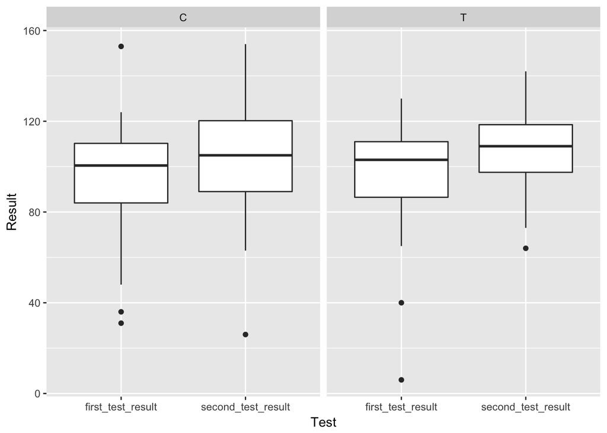

```r
ggplot(data = newData, mapping = aes(x = Test, y = Result)) +
        geom_boxplot() +
        facet_grid(~Type)
```

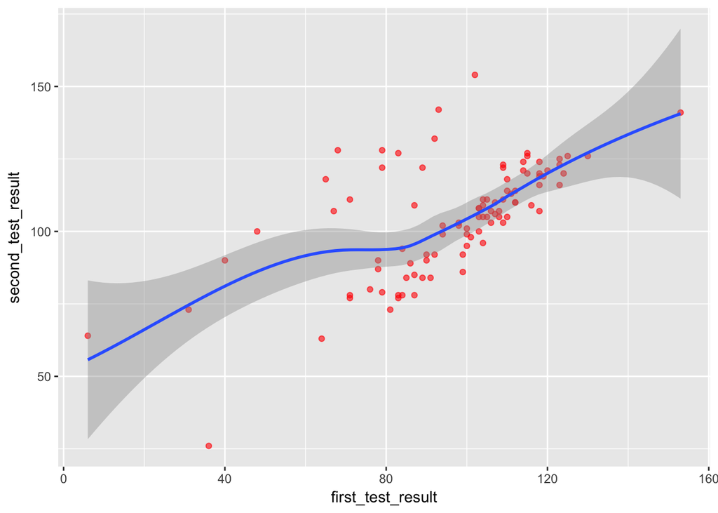

```r
ggplot(data = data, mapping = aes(x = first_test_result, y = second_test_result)) +
         geom_point(alpha = 0.6, colour = "red") +
        geom_smooth()
```

This histogram shows the distribution of the IQ test scores according to the type.

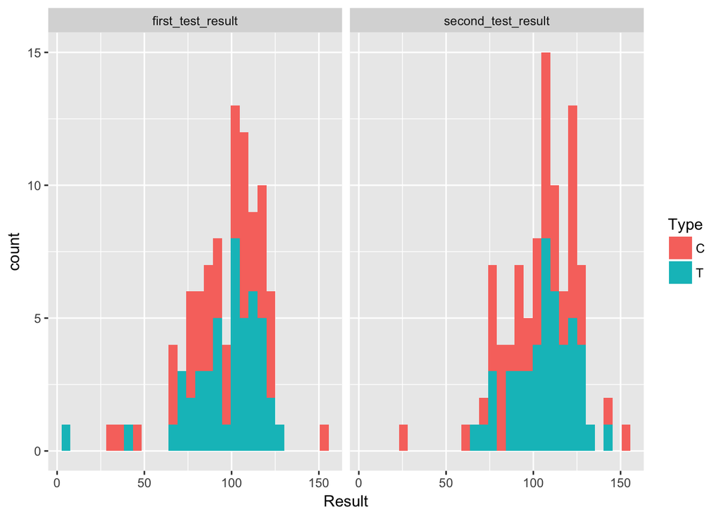

```r
ggplot(data = newData, mapping = aes(x = Result, fill = Type)) +
        geom_histogram() +
        facet_grid(~Test)
```